# **Spotify Analysis**

Member 1: Sophia Chen, Contribution: 85% (did not contribute to F).

Member 2: Katherine Li, Contribution: 80% (did not contribute to E).

Member 3: Shrey Nair, Contribution: 90% (did not contribute to F(conclusion)).

We, all team members, agree together that the above information is true, and we are confident about our contributions to this submitted project/final tutorial.

Sophia Chen 5/7/24 Katherine Li 5/7/24 Shrey Nair 5/7/24

Sophia Chen:

- Determined why we are interested in the topic and wrote the introduction.
- Helped preprocess the data by manually getting rid of songs with non utf-8 characters.
- Performed the statistical testing determining correlation between mode and popularity.
- Helped come up with which ML model would fit for our data.
- Calculated accuracy, precision, recall, and f1 score.
- Interpreted and analyzed decision tree visual.
- Created tutorial report and github repository.

Katherine Li:

- Came up with the original idea/topic
- Data curation and preprocessing
- Exploratory data analysis: ANOVA test to explore correlation b/w release date and popularity
- Drew insights about the relationship b/w songs' characteristics and Spotify popularity based on our testing results
- Wrote conclusion

Shrey Nair:

- Fine Tuned the initial idea, found datasets
- Assisted in cleaning and preprocessing the data
- ANOVA testing correlating keys and popularity
- Performed classification ML analysis using decision tree
- Create the visual for decision tree

### **Spring 2024 Data Science Project**

Sophia Chen, Katherine Li, Shrey Nair

# **Introduction**

Music is a core part of billions of lives all around the globe. On Spotify alone, there are 615 million users and 11 million artists. Here, we are analyzing songs to see how their different features correlate with their popularity, finding out what elements contribute to their stream counts. Some questions we are trying to answer are: What features most affect popularity and stream count? And does the time of a song’s release influence its popularity? These questions are important to explore so that artists know what would get them more streams, whether that be how to incorporate the specific features that enhance the songs or when they should release their music. Providing these insights to artists would help them optimize their reach and impact, revolutionizing the music industry.

# **Data Curation**

We used a kaggle dataset with details on various songs and their attributes pertaining to their associated artists, release dates, streams, etc.

Source: https://www.kaggle.com/datasets/nelgiriyewithana/top-spotify-songs-2023

```python
import pandas as pd
from scipy import stats
from scipy.stats import f_oneway
import numpy as np
import matplotlib.pyplot as plt
from sklearn.linear_model import LinearRegression
```

```python
charts_df = pd.read_csv('spotify_2023_clean.csv')
charts_df['key'] = charts_df['key'].astype(str)
charts_df.head()
```

|  | Unnamed: 0 | track_name | artist(s)_name | artist_count | released_year | released_month | released_day | in_spotify_playlists | in_spotify_charts | streams | bpm | key | mode | danceability_% | valence_% | energy_% | acousticness_% | instrumentalness_% | liveness_% | speechiness_% |
| --- | --- | --- | --- | --- | --- | --- | --- | --- | --- | --- | --- | --- | --- | --- | --- | --- | --- | --- | --- | --- |
| 0 | 0 | Seven (feat. Latto) (Explicit Ver.) | Latto, Jung Kook | 2 | 2023 | 7 | 14 | 553 | 147 | 141381703 | 125 | B | Major | 80 | 89 | 83 | 31 | 0 | 8 | 4 |
| 1 | 1 | LALA | Myke Towers | 1 | 2023 | 3 | 23 | 1474 | 48 | 133716286 | 92 | C# | Major | 71 | 61 | 74 | 7 | 0 | 10 | 4 |
| 2 | 2 | vampire | Olivia Rodrigo | 1 | 2023 | 6 | 30 | 1397 | 113 | 140003974 | 138 | F | Major | 51 | 32 | 53 | 17 | 0 | 31 | 6 |
| 3 | 3 | Cruel Summer | Taylor Swift | 1 | 2019 | 8 | 23 | 7858 | 100 | 800840817 | 170 | A | Major | 55 | 58 | 72 | 11 | 0 | 11 | 15 |
| 4 | 4 | WHERE SHE GOES | Bad Bunny | 1 | 2023 | 5 | 18 | 3133 | 50 | 303236322 | 144 | A | Minor | 65 | 23 | 80 | 14 | 63 | 11 | 6 |

# **Exploratory Data Analysis**

```python
print(f"Stream Mean: {int(charts_df['streams'].mean())}")
print(f"Stream Max: {int(charts_df['streams'].max())}")
print(f"Stream Min: {int(charts_df['streams'].min())}")
```

```
Stream Mean: 514137424
Stream Max: 3703895074
Stream Min: 2762
```

Statistical Method 1: Independent T-test

We are curious if different types of qualities of the tracks indicate the popularity of the song. Here, we are focusing on the mode. Since, there are two categories for mode (Major or Minor) we are using a t-test. Popularity can be seen through their rankings on spotify charts or streams, but we chose streams because streams from a song are independent from another song. We will be performing an independent t-test to see if there is statistically significant difference in the mean number of streams between songs in major and songs in minor.

*H0:* There isn't a difference between the mean number of streams between major and minor modes.

*HA:* There is a difference between the mean number of streams between major and minor modes.

Our alpha value here is 0.05.

```python
# splitting into Major and Minor Modes
major = charts_df[charts_df['mode'] == 'Major']['streams']
minor = charts_df[charts_df['mode'] == 'Minor']['streams']
# performming T-test
t, p_value = stats.ttest_ind(major, minor)
print("p-value:", p_value)
```

```
p-value: 0.1887329698746361
```

After performing the t-test, and comparing the p-value to the alpha value we will fail to reject *H0*, so there isn't enough evidence to conclude that there is a difference in the number of streams between the major and minor modes.

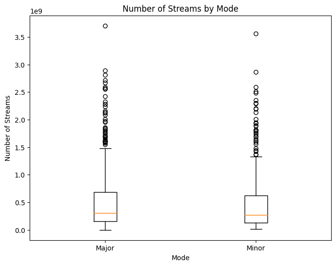

```python
# plotting box plot
plt.figure(figsize=(8, 6))
plt.boxplot([major, minor], labels=['Major', 'Minor'])
plt.title('Number of Streams by Mode')
plt.xlabel('Mode')
plt.ylabel('Number of Streams')
plt.show()
```

It appears that there is a slightly lower amount of streams for minor modes than major modes based on their median. Additionally, there are many outliers for major and minor modes from the boxplot.

Statistical Method 2: ANOVA

Here, we will be conducting an analysis on whether is a statistically significant difference in popularity with respects to the keys of a song which will also be accompanied by visuals comparing the magnitude in streams between the keys.

H0: The means of the streams of the keys are equal.

Ha: The means of the streams of the keys are unequal.

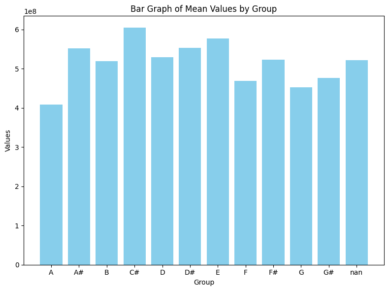

```
F-statistic: 0.8143668462846643
p-value: 0.6257490539641923
```

```python
# Computing the mean of 'streams' for each group
group_means = charts_df.groupby('key')['streams'].mean()
# Plotting a bar graph
plt.figure(figsize=(8, 6))
plt.bar(group_means.index, group_means, color='skyblue')
plt.xlabel('Group')
plt.ylabel('Values')
plt.title('Bar Graph of Mean Values by Group')
plt.tight_layout()  # Adjust layout to prevent clipping of labels
plt.show()

# Performing ANOVA test
grouped_data = [group["streams"].values for _, group in charts_df.groupby("key")]
f_stat, p_value = f_oneway(*grouped_data)
print("F-statistic:", f_stat)
print("p-value:", p_value)
```

Statistical Method 3: ANOVA

Using an ANOVA test to explore the relationship between a song's release date and its popularity/ranking\ H0: A song's release date has no effect on its popularity\ Ha: A song's release date has an effect on its popularity

```python
# only keeping relevant columns
charts_df = charts_df[['released_year', 'in_spotify_charts']]

# categorizing songs based on their release date: 2023, 2022, 2019-2021, and earlier
conditions = [
    (charts_df['released_year'] == 2023),
    (charts_df['released_year'] == 2022),
    (charts_df['released_year'] <= 2021) & (charts_df['released_year'] >= 2019),
    (charts_df['released_year'] <= 2018)
]
categories = ["2023", '2022', '2019 - 2021', '2018 and earlier']
charts_df['categories'] = np.select(conditions, categories)

# this column = max chart ranking - song's chart ranking, so that popular songs have a higher value in this column. This is useful for the bar graph later.
charts_df['charts_reversed'] = max(charts_df['in_spotify_charts']) - charts_df['in_spotify_charts']
```

```python
anova = stats.f_oneway(charts_df[charts_df['categories'] == '2023']['in_spotify_charts'],
                        charts_df[charts_df['categories'] == '2022']['in_spotify_charts'],
                        charts_df[charts_df['categories'] == '2019 - 2021']['in_spotify_charts'],
                        charts_df[charts_df['categories'] == '2018 and earlier']['in_spotify_charts'])
p = anova.pvalue
print(p)
```

```
4.955547828055869e-22
```

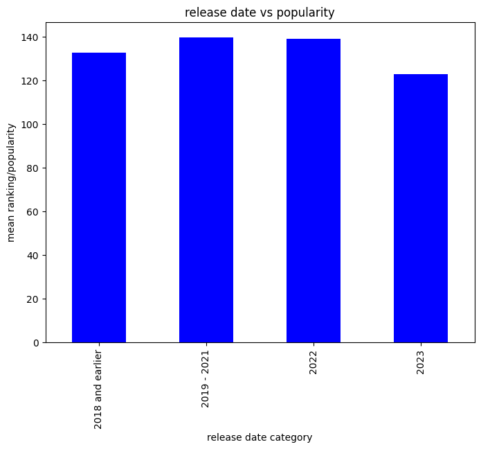

```python
plt.figure(figsize=(8, 6))
charts_df.groupby('categories')['charts_reversed'].mean().plot(kind='bar', color='blue')
plt.title('release date vs popularity')
plt.xlabel('release date category')
plt.ylabel('mean ranking/popularity')
plt.show()
```

Based on the graph, it seems like songs released the current year (2023) tend to rank lower on Spotify charts than the other categories.

# **Primary Analysis**

For our primary analysis, we began by creating a new column called 'pop_level' which would be assigned string values 'super' or 'moderate' based on whether the stream count for each song was either higher or lower than the median of the streams of all the songs in the dataset.

We subsequently began assigning the columns of 'danceability*%', 'energy*%', 'acousticness_%' values of 1,2,3 based on whether they fell into the respective ranges of 0-30, 31-70, or 71-100.

Afterwhich we used a decision tree to fit the song attribute columns against the stream count as well as calculate both the precision, accuracy, recall, and f1 score.

```python
import numpy as np
import pandas as pd
import matplotlib.pyplot as plt
from sklearn.tree import DecisionTreeClassifier, plot_tree
from sklearn.metrics import accuracy_score, precision_score, recall_score, f1_score


charts_df = pd.read_csv('spotify_2023_clean.csv')
charts_df['key'] = charts_df['key'].astype(str)

# Song's musical attributes
song_attr = ['danceability_%', 'energy_%', 'acousticness_%']

median_value = charts_df['streams'].median()
charts_df['pop_level'] = charts_df['streams'].apply(lambda x: 'super' if x > median_value else 'moderate')
for i in song_attr:
  charts_df[i] = charts_df[i].apply(lambda x: 1 if (x >= 0 and x <= 30) else 2 if (x >= 31 and x <= 70) else 3)

X = charts_df[song_attr]
y = charts_df['pop_level']

# Create and train the decision tree classifier
model = DecisionTreeClassifier()
model.fit(X, y)

prediction = model.predict(X)

# Calculating accuracy, precision, recall, and f1 score
accuracy = accuracy_score(y, prediction)
precision = precision_score(y, prediction, average='weighted')
recall = recall_score(y, prediction, average='weighted')
f1 = f1_score(y, prediction, average='weighted')

print("accuracy: ", accuracy)
print("precision: ", precision)
print("recall: ", recall)
print("f1 score: ", f1)
```

```
accuracy:  0.5798319327731093
precision:  0.5806520653492188
recall:  0.5798319327731093
f1 score:  0.5787610619469027
```

The accuracy, precision, recall, and f1 score of the decision tree classification model were all around 58%, meaning that it moderately performed for all.

# **Visualization**

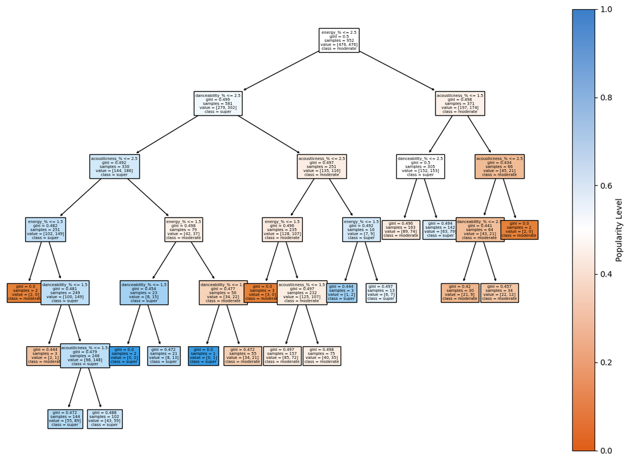

```python
import matplotlib.colors as mcolors

plt.figure(figsize=(15, 10))
plot_tree(model, feature_names=song_attr, class_names=['moderate', 'super'], filled=True)

#creating legend
cmap = mcolors.LinearSegmentedColormap.from_list('custom', ['#DF5E18','white','#3C7EC9'])
plt.colorbar(plt.cm.ScalarMappable(cmap=cmap), orientation='vertical', label='Popularity Level')

plt.show()
```

In this decision tree we are classifying songs based on their popularity level, either moderate or super. The color of the decision node corresponds to the separation of the songs: blue meaning more popular or super and orange being not as popular or moderate. Following the path to a leaf may indicate the features of the song to get to that popularity level. The decision tree slightly skewed but mostly balanced, indicating that the accuracy, precision, recall, and f1 score should be moderate.

# **Insights and Conclusions**